# [1]. Reading Data

## [1.1] Loading the data

The dataset is available in two forms

1. .csv file
2. SQLite Database

In order to load the data, We have used the SQLITE dataset as it is easier to query the data and visualise the data efficiently.

Here as we only want to get the global sentiment of the recommendations (positive or negative), we will purposefully ignore all Scores equal to 3. If the score is above 3, then the recommendation wil be set to "positive". Otherwise, it will be set to "negative".

```python
%matplotlib inline
import warnings
warnings.filterwarnings("ignore")


import sqlite3
import pandas as pd
import numpy as np
import nltk
import string
import matplotlib.pyplot as plt
import seaborn as sns
from sklearn.feature_extraction.text import TfidfTransformer
from sklearn.feature_extraction.text import TfidfVectorizer

from sklearn.feature_extraction.text import CountVectorizer
from sklearn.metrics import confusion_matrix
from sklearn import metrics
from sklearn.metrics import roc_curve, auc
from nltk.stem.porter import PorterStemmer

import re
# Tutorial about Python regular expressions: https://pymotw.com/2/re/
import string
from nltk.corpus import stopwords
from nltk.stem import PorterStemmer
from nltk.stem.wordnet import WordNetLemmatizer

from gensim.models import Word2Vec
from gensim.models import KeyedVectors
import pickle

from tqdm import tqdm
import os
```

```python
# using SQLite Table to read data.
con = sqlite3.connect('D:/AAIC/Data_Sets/amazon-fine-food-reviews/database.sqlite')

# filtering only positive and negative reviews i.e.
# not taking into consideration those reviews with Score=3
# SELECT * FROM Reviews WHERE Score != 3 LIMIT 500000, will give top 500000 data points
# you can change the number to any other number based on your computing power

# filtered_data = pd.read_sql_query(""" SELECT * FROM Reviews WHERE Score != 3 LIMIT 500000""", con)
# for tsne assignment you can take 5k data points

filtered_data = pd.read_sql_query(""" SELECT * FROM Reviews WHERE Score != 3 LIMIT 25000""", con)

# Give reviews with Score>3 a positive rating(1), and reviews with a score<3 a negative rating(0).
def partition(x):
    if x < 3:
        return 0
    return 1

#changing reviews with score less than 3 to be positive and vice-versa
actualScore = filtered_data['Score']
positiveNegative = actualScore.map(partition)
filtered_data['Score'] = positiveNegative
print("Number of data points in our data", filtered_data.shape)
filtered_data.head(3)
```

```
Number of data points in our data (25000, 10)
```

|  | Id | ProductId | UserId | ProfileName | HelpfulnessNumerator | HelpfulnessDenominator | Score | Time | Summary | Text |
| --- | --- | --- | --- | --- | --- | --- | --- | --- | --- | --- |
| 0 | 1 | B001E4KFG0 | A3SGXH7AUHU8GW | delmartian | 1 | 1 | 1 | 1303862400 | Good Quality Dog Food | I have bought several of the Vitality canned d... |
| 1 | 2 | B00813GRG4 | A1D87F6ZCVE5NK | dll pa | 0 | 0 | 0 | 1346976000 | Not as Advertised | Product arrived labeled as Jumbo Salted Peanut... |
| 2 | 3 | B000LQOCH0 | ABXLMWJIXXAIN | Natalia Corres "Natalia Corres" | 1 | 1 | 1 | 1219017600 | "Delight" says it all | This is a confection that has been around a fe... |

```python
display = pd.read_sql_query("""
SELECT UserId, ProductId, ProfileName, Time, Score, Text, COUNT(*)
FROM Reviews
GROUP BY UserId
HAVING COUNT(*)>1
""", con)
```

```python
print(display.shape)
display.head()
```

```
(80668, 7)
```

|  | UserId | ProductId | ProfileName | Time | Score | Text | COUNT(*) |
| --- | --- | --- | --- | --- | --- | --- | --- |
| 0 | #oc-R115TNMSPFT9I7 | B007Y59HVM | Breyton | 1331510400 | 2 | Overall its just OK when considering the price... | 2 |
| 1 | #oc-R11D9D7SHXIJB9 | B005HG9ET0 | Louis E. Emory "hoppy" | 1342396800 | 5 | My wife has recurring extreme muscle spasms, u... | 3 |
| 2 | #oc-R11DNU2NBKQ23Z | B007Y59HVM | Kim Cieszykowski | 1348531200 | 1 | This coffee is horrible and unfortunately not ... | 2 |
| 3 | #oc-R11O5J5ZVQE25C | B005HG9ET0 | Penguin Chick | 1346889600 | 5 | This will be the bottle that you grab from the... | 3 |
| 4 | #oc-R12KPBODL2B5ZD | B007OSBE1U | Christopher P. Presta | 1348617600 | 1 | I didnt like this coffee. Instead of telling y... | 2 |

```python
display[display['UserId']=='AZY10LLTJ71NX']
```

|  | UserId | ProductId | ProfileName | Time | Score | Text | COUNT(*) |
| --- | --- | --- | --- | --- | --- | --- | --- |
| 80638 | AZY10LLTJ71NX | B006P7E5ZI | undertheshrine "undertheshrine" | 1334707200 | 5 | I was recommended to try green tea extract to ... | 5 |

```python
display['COUNT(*)'].sum()
```

```
393063
```

# [2] Exploratory Data Analysis

## [2.1] Data Cleaning: Deduplication

It is observed (as shown in the table below) that the reviews data had many duplicate entries. Hence it was necessary to remove duplicates in order to get unbiased results for the analysis of the data. Following is an example:

```python
display= pd.read_sql_query("""
SELECT *
FROM Reviews
WHERE Score != 3 AND UserId="AR5J8UI46CURR"
ORDER BY ProductID
""", con)
display.head()
```

|  | Id | ProductId | UserId | ProfileName | HelpfulnessNumerator | HelpfulnessDenominator | Score | Time | Summary | Text |
| --- | --- | --- | --- | --- | --- | --- | --- | --- | --- | --- |
| 0 | 78445 | B000HDL1RQ | AR5J8UI46CURR | Geetha Krishnan | 2 | 2 | 5 | 1199577600 | LOACKER QUADRATINI VANILLA WAFERS | DELICIOUS WAFERS. I FIND THAT EUROPEAN WAFERS ... |
| 1 | 138317 | B000HDOPYC | AR5J8UI46CURR | Geetha Krishnan | 2 | 2 | 5 | 1199577600 | LOACKER QUADRATINI VANILLA WAFERS | DELICIOUS WAFERS. I FIND THAT EUROPEAN WAFERS ... |
| 2 | 138277 | B000HDOPYM | AR5J8UI46CURR | Geetha Krishnan | 2 | 2 | 5 | 1199577600 | LOACKER QUADRATINI VANILLA WAFERS | DELICIOUS WAFERS. I FIND THAT EUROPEAN WAFERS ... |
| 3 | 73791 | B000HDOPZG | AR5J8UI46CURR | Geetha Krishnan | 2 | 2 | 5 | 1199577600 | LOACKER QUADRATINI VANILLA WAFERS | DELICIOUS WAFERS. I FIND THAT EUROPEAN WAFERS ... |
| 4 | 155049 | B000PAQ75C | AR5J8UI46CURR | Geetha Krishnan | 2 | 2 | 5 | 1199577600 | LOACKER QUADRATINI VANILLA WAFERS | DELICIOUS WAFERS. I FIND THAT EUROPEAN WAFERS ... |

```python
#Sorting data according to ProductId in ascending order
sorted_data=filtered_data.sort_values('ProductId', axis=0, ascending=True, inplace=False, kind='quicksort', na_position='last')
```

```python
#Deduplication of entries
final=sorted_data.drop_duplicates(subset={"UserId","ProfileName","Time","Text"}, keep='first', inplace=False)
final.shape
```

```
(23953, 10)
```

```python
#Checking to see how much % of data still remains
(final['Id'].size*1.0)/(filtered_data['Id'].size*1.0)*100
```

```
95.812
```

**Observation:-** It was also seen that in two rows given below the value of HelpfulnessNumerator is greater than HelpfulnessDenominator which is not practically possible hence these two rows too are removed from calcualtions

```python
display= pd.read_sql_query("""
SELECT *
FROM Reviews
WHERE Score != 3 AND Id=44737 OR Id=64422
ORDER BY ProductID
""", con)

display.head()
```

|  | Id | ProductId | UserId | ProfileName | HelpfulnessNumerator | HelpfulnessDenominator | Score | Time | Summary | Text |
| --- | --- | --- | --- | --- | --- | --- | --- | --- | --- | --- |
| 0 | 64422 | B000MIDROQ | A161DK06JJMCYF | J. E. Stephens "Jeanne" | 3 | 1 | 5 | 1224892800 | Bought This for My Son at College | My son loves spaghetti so I didn't hesitate or... |
| 1 | 44737 | B001EQ55RW | A2V0I904FH7ABY | Ram | 3 | 2 | 4 | 1212883200 | Pure cocoa taste with crunchy almonds inside | It was almost a 'love at first bite' - the per... |

```python
final=final[final.HelpfulnessNumerator<=final.HelpfulnessDenominator]
```

```python
#Before starting the next phase of preprocessing lets see the number of entries left
print(final.shape)

#How many positive and negative reviews are present in our dataset?
final['Score'].value_counts()
```

```
(23953, 10)
```

```
1    20071
0     3882
Name: Score, dtype: int64
```

## Observations:

1. The given data set is an imbalanced dataset.

# [3] Preprocessing

## [3.1]. Preprocessing Review Text

Now that we have finished deduplication our data requires some preprocessing before we go on further with analysis and making the prediction model.

After which we collect the words used to describe positive and negative reviews

```python
# https://stackoverflow.com/a/47091490/4084039
import re
from bs4 import BeautifulSoup
def decontracted(phrase):
    # specific
    phrase = re.sub(r"won't", "will not", phrase)
    phrase = re.sub(r"can\'t", "can not", phrase)

    # general
    phrase = re.sub(r"n\'t", " not", phrase)
    phrase = re.sub(r"\'re", " are", phrase)
    phrase = re.sub(r"\'s", " is", phrase)
    phrase = re.sub(r"\'d", " would", phrase)
    phrase = re.sub(r"\'ll", " will", phrase)
    phrase = re.sub(r"\'t", " not", phrase)
    phrase = re.sub(r"\'ve", " have", phrase)
    phrase = re.sub(r"\'m", " am", phrase)
    return phrase
```

```python
# https://gist.github.com/sebleier/554280
# we are removing the words from the stop words list: 'no', 'nor', 'not'
# <br /><br /> ==> after the above steps, we are getting "br br"
# we are including them into stop words list
# instead of <br /> if we have <br/> these tags would have revmoved in the 1st step

stopwords= set(['br', 'the', 'i', 'me', 'my', 'myself', 'we', 'our', 'ours', 'ourselves', 'you', "you're", "you've",\
            "you'll", "you'd", 'your', 'yours', 'yourself', 'yourselves', 'he', 'him', 'his', 'himself', \
            'she', "she's", 'her', 'hers', 'herself', 'it', "it's", 'its', 'itself', 'they', 'them', 'their',\
            'theirs', 'themselves', 'what', 'which', 'who', 'whom', 'this', 'that', "that'll", 'these', 'those', \
            'am', 'is', 'are', 'was', 'were', 'be', 'been', 'being', 'have', 'has', 'had', 'having', 'do', 'does', \
            'did', 'doing', 'a', 'an', 'the', 'and', 'but', 'if', 'or', 'because', 'as', 'until', 'while', 'of', \
            'at', 'by', 'for', 'with', 'about', 'against', 'between', 'into', 'through', 'during', 'before', 'after',\
            'above', 'below', 'to', 'from', 'up', 'down', 'in', 'out', 'on', 'off', 'over', 'under', 'again', 'further',\
            'then', 'once', 'here', 'there', 'when', 'where', 'why', 'how', 'all', 'any', 'both', 'each', 'few', 'more',\
            'most', 'other', 'some', 'such', 'only', 'own', 'same', 'so', 'than', 'too', 'very', \
            's', 't', 'can', 'will', 'just', 'don', "don't", 'should', "should've", 'now', 'd', 'll', 'm', 'o', 're', \
            've', 'y', 'ain', 'aren', "aren't", 'couldn', "couldn't", 'didn', "didn't", 'doesn', "doesn't", 'hadn',\
            "hadn't", 'hasn', "hasn't", 'haven', "haven't", 'isn', "isn't", 'ma', 'mightn', "mightn't", 'mustn',\
            "mustn't", 'needn', "needn't", 'shan', "shan't", 'shouldn', "shouldn't", 'wasn', "wasn't", 'weren', "weren't", \
            'won', "won't", 'wouldn', "wouldn't"])
```

```python
# Combining all the above stundents
from tqdm import tqdm
preprocessed_reviews = []
# tqdm is for printing the status bar
for sentance in tqdm(final['Text'].values):
    sentance = re.sub(r"http\S+", "", sentance)
    sentance = BeautifulSoup(sentance, 'lxml').get_text()
    sentance = decontracted(sentance)
    sentance = re.sub("\S*\d\S*", "", sentance).strip()
    sentance = re.sub('[^A-Za-z]+', ' ', sentance)
    # https://gist.github.com/sebleier/554280
    sentance = ' '.join(e.lower() for e in sentance.split() if e.lower() not in stopwords)
    preprocessed_reviews.append(sentance.strip())
```

```python
preprocessed_reviews[1500]
```

```
'bread good taste not rise properly makes loaf checked temp water suggested bad results raising temp degrees got rise loaf pretty expensive quality not buy'
```

# Preparing Data points (into Train and Test)

There will be an issue of data-leakage if vectorize the entire data and then split it into train/cv/test.

```python
#divide preprocessed review data to Train and Test dataset using train_test_split
from sklearn.model_selection import train_test_split
from sklearn import preprocessing

#Breaking into Train and test
X_train, X_test, Y_train, Y_test = train_test_split(preprocessed_reviews,final['Score'].values,test_size=0.3,shuffle=False)
pd.DataFrame(Y_train)[0].value_counts()
```

```
1    14039
0     2728
Name: 0, dtype: int64
```

```python
NoofDataPoint_Train = len(X_train);
X_train = X_train[:NoofDataPoint_Train]
Y_train = Y_train[:NoofDataPoint_Train]
NoOfDataPoints_Test = len(X_test);
X_test = X_test[0:NoOfDataPoints_Test]
Y_test = Y_test[:NoOfDataPoints_Test]

#Let No of ngramRange be 1 = UniGram
uni_gram = CountVectorizer()
X_train = uni_gram.fit_transform(X_train)
X_test = uni_gram.transform(X_test)

#Normalizing the  Data
X_train = preprocessing.normalize(X_train)
X_test = preprocessing.normalize(X_test)
```

```python
from sklearn.model_selection import TimeSeriesSplit
TimeBasedSplittingMachine = TimeSeriesSplit(n_splits=10)
for train, cv in TimeBasedSplittingMachine.split(X_train):
    #print("%s %s" % (train, cv))
    print(X_train[train].shape, X_train[cv].shape)

X_train.shape
```

```
(1527, 24501) (1524, 24501)
(3051, 24501) (1524, 24501)
(4575, 24501) (1524, 24501)
(6099, 24501) (1524, 24501)
(7623, 24501) (1524, 24501)
(9147, 24501) (1524, 24501)
(10671, 24501) (1524, 24501)
(12195, 24501) (1524, 24501)
(13719, 24501) (1524, 24501)
(15243, 24501) (1524, 24501)
```

```
(16767, 24501)
```

# [4] Featurization

## [4.1] BAG OF WORDS

## 4.1.1 Applying KNN brute force on BOW

```python
Max_No_Of_Neighbours = 100;
K_Value_List_odd = list(range(1,Max_No_Of_Neighbours,2))
```

```python
%%time
TimeBasedSplittingMachine = TimeSeriesSplit(n_splits=10)
from sklearn.neighbors import KNeighborsClassifier
from sklearn.model_selection import cross_validate
from sklearn.metrics import precision_score, recall_score, roc_curve
from sklearn.model_selection import learning_curve

train_scores_Aw2v_bru=[]

i=1

for K in tqdm(K_Value_List_odd):
    #KNN for each K value using all processors
    KNN_model_Aw2v_bru = KNeighborsClassifier(n_neighbors = K,algorithm='brute', n_jobs = -1)
    #if i%5 == 0:
     #   print('='*i)
    train_score = cross_validate(KNN_model_Aw2v_bru, X_train, Y_train, cv=8, scoring='roc_auc',return_train_score=True)
    train_scores_Aw2v_bru.append(train_score)
    i=i+1
```

```
Wall time: 2h 13min 40s
```

```python
#taking a copy of scores because of naming convention
train_scores_Bow_bru = train_scores_Aw2v_bru
```

```python
Val_Score_Bow_bru=[];
Training_Score_Bow_bru = []

for i in tqdm(train_scores_Bow_bru):
    Val_Score_Bow_bru.append(i.get('test_score').mean()*100)
    Training_Score_Bow_bru.append(i.get('train_score').mean()*100)
```

```python
#below is best k value based on train and validation scores but K Value based on the min diff bwn train and validation score
# is taken below
Best_K_Value_val = K_Value_List_odd[Val_Score_Bow_bru.index(max(Val_Score_Bow_bru))]
Best_K_Value_train = K_Value_List_odd[Training_Score_Bow_bru.index(max(Training_Score_Bow_bru))]
print("The best K value:",Best_K_Value_val)
```

```
The best K value: 99
```

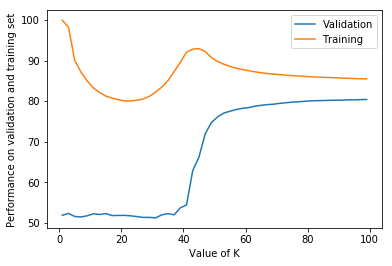

```python
plt.plot(K_Value_List_odd, Val_Score_Bow_bru, label="Validation")
plt.plot(K_Value_List_odd, Training_Score_Bow_bru, label="Training")
plt.xlabel("Value of K");
plt.ylabel("Performance on validation and training set")
plt.legend()
```

```python
#Computing difference of Training score and validation score
for_opt_k = []
for k in range(len(K_Value_List_odd)):
    for_opt_k.append(Training_Score_Bow_bru[k] - Val_Score_Bow_bru[k])
```

```python
#K Value based on the min diff bwn train and validation score
K_Value_to_train_bow_bru = K_Value_List_odd[for_opt_k.index(min(for_opt_k))]
```

```python
knn_to_fit_the_best = KNeighborsClassifier(n_neighbors=K_Value_to_train_bow_bru,algorithm='brute')
knn_to_fit_the_best.fit(X_train, Y_train)
#predicting values on test data
Prediction_test = knn_to_fit_the_best.predict(X_test)
#predicting probabilities on test data
Prediction_prob_test = knn_to_fit_the_best.predict_proba(X_test)
```

```python
#predicting values on train data
Prediction_train = knn_to_fit_the_best.predict(X_train)
#predicting probabilities on train data
Prediction_prob_train = knn_to_fit_the_best.predict_proba(X_train)
```

```python
from sklearn.metrics import roc_curve, auc

#computing ROC curve parameters
fpr, tpr, thresholds = roc_curve( Y_train, Prediction_prob_train[:,1])
fpr_test, tpr_test, thresholds_test = roc_curve( Y_test, Prediction_prob_test[:,1])
#computing AUC value on prediction over train data
roc_auc_train = auc(fpr, tpr)
#computing AUC value on prediction over test data
roc_auc_test = auc(fpr_test, tpr_test)
```

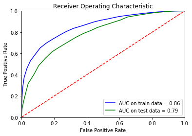

```python
#Plotting ROC Curve
import matplotlib.pyplot as plt
plt.title('Receiver Operating Characteristic')
plt.plot(fpr, tpr, 'b', label = 'AUC on train data = %0.2f' % roc_auc_train)

plt.plot(fpr_test, tpr_test, 'g', label = 'AUC on test data = %0.2f' % roc_auc_test)
plt.legend(loc = 'lower right')
plt.plot([0, 1], [0, 1],'r--')
plt.xlim([0, 1])
plt.ylim([0, 1])
plt.ylabel('True Positive Rate')
plt.xlabel('False Positive Rate')
plt.show()
```

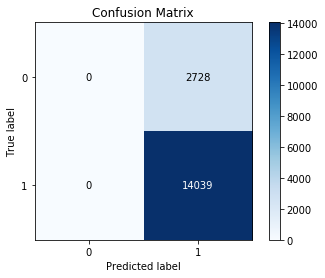

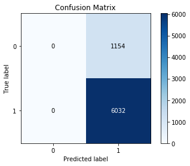

```python
#confusion matirx
import scikitplot.metrics as skplt
# for train data prediction
skplt.plot_confusion_matrix(Y_train, Prediction_train)
#for test data prediction
skplt.plot_confusion_matrix(Y_test, Prediction_test )
```

## -------------------------- End of Brute - BoW -------------------------------------

## 4.1.2 BOW - Kd-Tree

```python
X_train_1000 = X_train[:,:500]
print(X_train_1000.shape)
print(Y_train.shape)
print(pd.DataFrame(Y_train)[0].value_counts())
#Y_train_1000 = Y_train
#print(Y_train_1000.shape)
```

```
(16767, 500)
(16767,)
1    14039
0     2728
Name: 0, dtype: int64
```

```python
Max_No_Of_Neighbours = 100;
K_Value_List_odd = list(range(1,Max_No_Of_Neighbours,2))
```

```python
%%time
#TimeBasedSplittingMachine = TimeSeriesSplit(n_splits=10)
from sklearn.neighbors import KNeighborsClassifier
from sklearn.model_selection import cross_validate
from sklearn.metrics import precision_score, recall_score, roc_curve
from sklearn.model_selection import learning_curve

train_scores_Bow_Kd=[]

i=1

for K in tqdm(K_Value_List_odd):
    #KNN for each K value using all processors
    KNN_model_BoW_Kd = KNeighborsClassifier(n_neighbors = K,algorithm='kd_tree', n_jobs = -1)
    train_score = cross_validate(KNN_model_BoW_Kd, X_train_1000, Y_train, cv=5, scoring='roc_auc',return_train_score=True)
    train_scores_Bow_Kd.append(train_score)
```

```
Wall time: 57min 16s
```

```python
Val_Score_Bow_kd=[];
Training_Score_Bow_kd = []

for i in tqdm(train_scores_Bow_Kd):
    Val_Score_Bow_kd.append(i.get('test_score').mean()*100)
    Training_Score_Bow_kd.append(i.get('train_score').mean()*100)
```

```
Text(99,80.4153,'(99,80.41525068323263)')
```

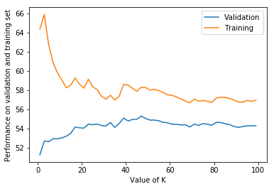

```python
plt.plot(K_Value_List_odd, Val_Score_Bow_kd, label="Validation")
plt.plot(K_Value_List_odd, Training_Score_Bow_kd, label="Training")
plt.xlabel("Value of K");
plt.ylabel("Performance on validation and training set")
plt.legend()
plt.annotate('(%s,%s)'%xy, xy=xy, textcoords='data')
```

```python
%%time
from sklearn.metrics import roc_curve, auc

#computing difference of Training score and validation score
for_opt_k = []
for k in range(len(K_Value_List_odd)):
    for_opt_k.append(Training_Score_Bow_kd[k] - Val_Score_Bow_kd[k])

#K Value based on the min of diff bwn train and validation score
K_Value_to_train = K_Value_List_odd[for_opt_k.index(min(for_opt_k))]
print(K_Value_to_train)
#Training on K found
knn_to_fit_the_best = KNeighborsClassifier(n_neighbors=K_Value_to_train,algorithm='brute')
knn_to_fit_the_best.fit(X_train, Y_train)
#predicting values on test data
Prediction_test = knn_to_fit_the_best.predict(X_test)
#predicting probabilities on test data
Prediction_prob_test = knn_to_fit_the_best.predict_proba(X_test)

#predicting values on train data
Prediction_train = knn_to_fit_the_best.predict(X_train)
#predicting probabilities on train data
Prediction_prob_train = knn_to_fit_the_best.predict_proba(X_train)

#computing ROC curve parameters
fpr, tpr, thresholds = roc_curve( Y_train, Prediction_prob_train[:,1])
fpr_test, tpr_test, thresholds_test = roc_curve( Y_test, Prediction_prob_test[:,1])
#computing AUC value on prediction over train data
roc_auc_train_Bow_kd = auc(fpr, tpr)
#computing AUC value on prediction over test data
roc_auc_test_Bow_kd = auc(fpr_test, tpr_test)
```

```
77
Wall time: 32.7 s
```

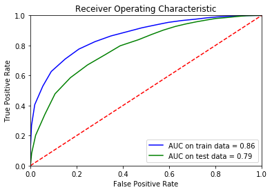

```python
#Plotting ROC Curve
import matplotlib.pyplot as plt
plt.title('Receiver Operating Characteristic')
plt.plot(fpr, tpr, 'b', label = 'AUC on train data = %0.2f' % roc_auc_train_Bow_kd)

plt.plot(fpr_test, tpr_test, 'g', label = 'AUC on test data = %0.2f' % roc_auc_test_Bow_kd)
plt.legend(loc = 'lower right')
plt.plot([0, 1], [0, 1],'r--')
plt.xlim([0, 1])
plt.ylim([0, 1])
plt.ylabel('True Positive Rate')
plt.xlabel('False Positive Rate')
plt.show()
```

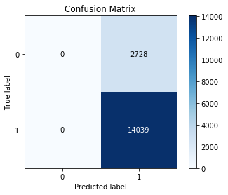

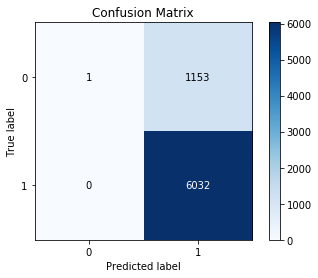

```python
#confusion matirx
import scikitplot.metrics as skplt
# for train data prediction
skplt.plot_confusion_matrix(Y_train, Prediction_train)
#for test data prediction
skplt.plot_confusion_matrix(Y_test, Prediction_test )
```

## --------------------------------- End Of BoW-KdTree ---------------------------------------

# ---------------------------------Assignment done till here ---------------------------------------

## [4.2] Bi-Grams and n-Grams.

```python
#bi-gram, tri-gram and n-gram

#removing stop words like "not" should be avoided before building n-grams
# count_vect = CountVectorizer(ngram_range=(1,2))
# please do read the CountVectorizer documentation http://scikit-learn.org/stable/modules/generated/sklearn.feature_extraction.text.CountVectorizer.html

# you can choose these numebrs min_df=10, max_features=5000, of your choice
count_vect = CountVectorizer(ngram_range=(1,2), min_df=10, max_features=5000)
final_bigram_counts = count_vect.fit_transform(preprocessed_reviews)
print("the type of count vectorizer ",type(final_bigram_counts))
print("the shape of out text BOW vectorizer ",final_bigram_counts.get_shape())
print("the number of unique words including both unigrams and bigrams ", final_bigram_counts.get_shape()[1])
```

## [4.3] TF-IDF

## 4.3.1 Tf-Idf - KdTree

```python
#divide preprocessed review data to Train and Test dataset using train_test_split
from sklearn.model_selection import train_test_split
from sklearn import preprocessing

#Breaking into Train and test
X_train, X_test, Y_train, Y_test = train_test_split(preprocessed_reviews,final['Score'].values,test_size=0.3,shuffle=False)
```

```python
#Using uni- and bi-grams
tfidf = TfidfVectorizer(ngram_range=(1,2))
#Taking only 500 dimensions
X_train = tfidf.fit_transform(X_train)
#Normalize Data
X_train = preprocessing.normalize(X_train)
X_test = tfidf.transform(X_test)
#Normalize Data
X_test = preprocessing.normalize(X_test)

X_train = X_train[:,:500]
X_test = X_test[:,:500]

print("Train Data Size: ",X_train.shape)
print("Test Data Size: ",X_test.shape)
```

```
Train Data Size:  (16767, 500)
Test Data Size:  (7186, 500)
```

```python
Max_No_Of_Neighbours = 100;
K_Value_List_odd = list(range(1,Max_No_Of_Neighbours,2))
```

```python
%%time
TimeBasedSplittingMachine = TimeSeriesSplit(n_splits=10)
from sklearn.neighbors import KNeighborsClassifier
from sklearn.model_selection import cross_validate
from sklearn.metrics import precision_score, recall_score, roc_curve
from sklearn.model_selection import learning_curve

train_scores_tfidf_kd=[]

for K in tqdm(K_Value_List_odd):
    #KNN for each K value using all processors
    KNN_model_Tfidf_Kd = KNeighborsClassifier(n_neighbors = K,algorithm='kd_tree', n_jobs = -1)
    train_score = cross_validate(KNN_model_Tfidf_Kd, X_train, Y_train, cv=10, scoring='roc_auc',return_train_score=True)
    train_scores_tfidf_kd.append(train_score)
```

```
Wall time: 2h 34min 41s
```

```python
Val_Score_tfidf_kd=[];
Training_Score_tfidf_kd = []

for i in tqdm(train_scores_tfidf_kd):
    Val_Score_tfidf_kd.append(i.get('test_score').mean()*100)
    Training_Score_tfidf_kd.append(i.get('train_score').mean()*100)
```

```
Text(99,80.4153,'(99,80.41525068323263)')
```

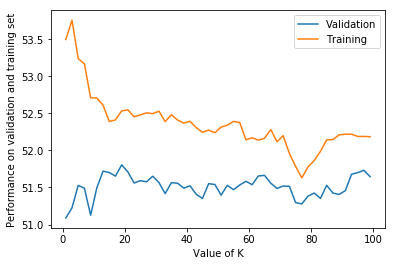

```python
plt.plot(K_Value_List_odd, Val_Score_tfidf_kd, label="Validation")
plt.plot(K_Value_List_odd, Training_Score_tfidf_kd, label="Training")
plt.xlabel("Value of K");
plt.ylabel("Performance on validation and training set")
plt.legend()
plt.annotate('(%s,%s)'%xy, xy=xy, textcoords='data')
```

```python
%%time
from sklearn.metrics import roc_curve, auc

#computing difference of Training score and validation score
for_opt_k = []
for k in range(len(K_Value_List_odd)):
    for_opt_k.append(Training_Score_tfidf_kd[k] - Val_Score_tfidf_kd[k])

#K Value based on the min of diff bwn train and validation score
K_Value_to_train_tf_kd = K_Value_List_odd[for_opt_k.index(min(for_opt_k))]
print(K_Value_to_train_tf_kd)
#Training on K found
knn_to_fit_the_best = KNeighborsClassifier(n_neighbors=K_Value_to_train_tf_kd,algorithm='brute')
knn_to_fit_the_best.fit(X_train, Y_train)
#predicting values on test data
Prediction_test = knn_to_fit_the_best.predict(X_test)
#predicting probabilities on test data
Prediction_prob_test = knn_to_fit_the_best.predict_proba(X_test)

#predicting values on train data
Prediction_train = knn_to_fit_the_best.predict(X_train)
#predicting probabilities on train data
Prediction_prob_train = knn_to_fit_the_best.predict_proba(X_train)

#computing ROC curve parameters
fpr, tpr, thresholds = roc_curve( Y_train, Prediction_prob_train[:,1])
fpr_test, tpr_test, thresholds_test = roc_curve( Y_test, Prediction_prob_test[:,1])
#computing AUC value on prediction over train data
roc_auc_train_tfidf_kd = auc(fpr, tpr)
#computing AUC value on prediction over test data
roc_auc_test_tfidf_kd = auc(fpr_test, tpr_test)
```

```
77
Wall time: 38.2 s
```

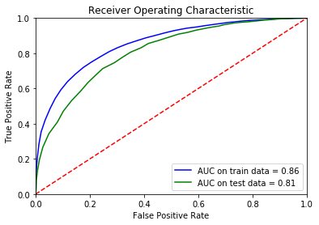

```python
#Plotting ROC Curve
import matplotlib.pyplot as plt
plt.title('Receiver Operating Characteristic')
plt.plot(fpr, tpr, 'b', label = 'AUC on train data = %0.2f' % roc_auc_train_tfidf_kd)

plt.plot(fpr_test, tpr_test, 'g', label = 'AUC on test data = %0.2f' % roc_auc_test_tfidf_kd)
plt.legend(loc = 'lower right')
plt.plot([0, 1], [0, 1],'r--')
plt.xlim([0, 1])
plt.ylim([0, 1])
plt.ylabel('True Positive Rate')
plt.xlabel('False Positive Rate')
plt.show()
```

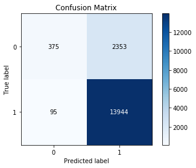

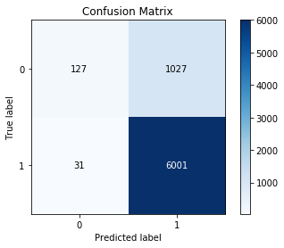

```python
#confusion matirx
import scikitplot.metrics as skplt
# for train data prediction
skplt.plot_confusion_matrix(Y_train, Prediction_train)
#for test data prediction
skplt.plot_confusion_matrix(Y_test, Prediction_test )
```

## 4.3.2 TfIdf - Brute

```python
#divide preprocessed review data to Train and Test dataset using train_test_split
from sklearn.model_selection import train_test_split
from sklearn import preprocessing

#Breaking into Train and test
X_train, X_test, Y_train, Y_test = train_test_split(preprocessed_reviews,final['Score'].values,test_size=0.3,shuffle=False)
```

```python
#Using uni- and bi-grams
tfidf = TfidfVectorizer(ngram_range=(1,2))
#Taking only 500 dimensions
X_train = tfidf.fit_transform(X_train)
#Normalize Data
X_train = preprocessing.normalize(X_train)
print("Train Data Size: ",X_train.shape)
X_test = tfidf.transform(X_test)
#Normalize Data
X_test = preprocessing.normalize(X_test)
print("Test Data Size: ",X_test.shape)
```

```
Train Data Size:  (16767, 392730)
Test Data Size:  (7186, 392730)
```

```python
%%time
TimeBasedSplittingMachine = TimeSeriesSplit(n_splits=10)
from sklearn.neighbors import KNeighborsClassifier
from sklearn.model_selection import cross_validate
from sklearn.metrics import precision_score, recall_score, roc_curve
from sklearn.model_selection import learning_curve

train_scores_tfidf_bru=[]


for K in K_Value_List_odd:
    #KNN for each K value using all processors
    KNN_model_tf_bru = KNeighborsClassifier(n_neighbors = K,algorithm='brute', n_jobs = -1)

    train_score = cross_validate(KNN_model_tf_bru, X_train, Y_train, cv=8, scoring='roc_auc',return_train_score=True)
    train_scores_tfidf_bru.append(train_score)
```

```
Wall time: 2h 10min 20s
```

```python
Val_Score_tfidf_bru=[];
Training_Score_tfidf_bru = []

for i in tqdm(train_scores_tfidf_bru):
    Val_Score_tfidf_bru.append(i.get('test_score').mean()*100)
    Training_Score_tfidf_bru.append(i.get('train_score').mean()*100)
```

```
Text(99,80.4153,'(99,80.41525068323263)')
```

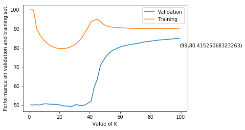

```python
plt.plot(K_Value_List_odd, Val_Score_tfidf_bru, label="Validation")
plt.plot(K_Value_List_odd, Training_Score_tfidf_bru, label="Training")
plt.xlabel("Value of K");
plt.ylabel("Performance on validation and training set")
plt.legend()
plt.annotate('(%s,%s)'%xy, xy=xy, textcoords='data')
```

```python
%%time
from sklearn.metrics import roc_curve, auc

#computing difference of Training score and validation score
for_opt_k = []
for k in range(len(K_Value_List_odd)):
    for_opt_k.append(abs(Training_Score_tfidf_bru[k] - Val_Score_tfidf_bru[k]))

#K Value based on the min of diff bwn train and validation score
K_Value_to_train_tfidf_bru = K_Value_List_odd[for_opt_k.index(min(for_opt_k))]
print(K_Value_to_train_tfidf_bru)
#Training on K found
knn_to_fit_the_best = KNeighborsClassifier(n_neighbors=K_Value_to_train_tfidf_bru,algorithm='brute')
knn_to_fit_the_best.fit(X_train, Y_train)
#predicting values on test data
Prediction_test = knn_to_fit_the_best.predict(X_test)
#predicting probabilities on test data
Prediction_prob_test = knn_to_fit_the_best.predict_proba(X_test)

#predicting values on train data
Prediction_train = knn_to_fit_the_best.predict(X_train)
#predicting probabilities on train data
Prediction_prob_train = knn_to_fit_the_best.predict_proba(X_train)

#computing ROC curve parameters
fpr, tpr, thresholds = roc_curve( Y_train, Prediction_prob_train[:,1])
fpr_test, tpr_test, thresholds_test = roc_curve( Y_test, Prediction_prob_test[:,1])
#computing AUC value on prediction over train data
roc_auc_train_tfidf_bru = auc(fpr, tpr)
#computing AUC value on prediction over test data
roc_auc_test_tfidf_bru = auc(fpr_test, tpr_test)
```

```
99
Wall time: 39.6 s
```

```python
#Plotting ROC Curve
import matplotlib.pyplot as plt
plt.title('Receiver Operating Characteristic')
plt.plot(fpr, tpr, 'b', label = 'AUC on train data = %0.2f' % roc_auc_train_tfidf_bru)

plt.plot(fpr_test, tpr_test, 'g', label = 'AUC on test data = %0.2f' % roc_auc_test_tfidf_bru)
plt.legend(loc = 'lower right')
plt.plot([0, 1], [0, 1],'r--')
plt.xlim([0, 1])
plt.ylim([0, 1])
plt.ylabel('True Positive Rate')
plt.xlabel('False Positive Rate')
plt.show()
```

```python
#confusion matirx
import scikitplot.metrics as skplt
# for train data prediction
skplt.plot_confusion_matrix(Y_train, Prediction_train)
#for test data prediction
skplt.plot_confusion_matrix(Y_test, Prediction_test )
```

## [4.4] Word2Vec

```python
# Train your own Word2Vec model using your own text corpus
i=0
list_of_sentance=[]
for sentance in tqdm(preprocessed_reviews):
    list_of_sentance.append(sentance.split())
```

```python
# Using Google News Word2Vectors

# in this project we are using a pretrained model by google
# its 3.3G file, once you load this into your memory
# it occupies ~9Gb, so please do this step only if you have >12G of ram
# we will provide a pickle file wich contains a dict ,
# and it contains all our courpus words as keys and  model[word] as values
# To use this code-snippet, download "GoogleNews-vectors-negative300.bin"
# from https://drive.google.com/file/d/0B7XkCwpI5KDYNlNUTTlSS21pQmM/edit
# it's 1.9GB in size.


# http://kavita-ganesan.com/gensim-word2vec-tutorial-starter-code/#.W17SRFAzZPY
# you can comment this whole cell
# or change these varible according to your need

is_your_ram_gt_16g=False
want_to_use_google_w2v = False
want_to_train_w2v = True

if want_to_train_w2v:
    # min_count = 5 considers only words that occured atleast 5 times
    w2v_model=Word2Vec(list_of_sentance,min_count=5,size=50, workers=4)
    print(w2v_model.wv.most_similar('great'))
    print('='*500)
    print(w2v_model.wv.most_similar('worst'))

elif want_to_use_google_w2v and is_your_ram_gt_16g:
    if os.path.isfile('GoogleNews-vectors-negative300.bin'):
        w2v_model=KeyedVectors.load_word2vec_format('GoogleNews-vectors-negative300.bin', binary=True)
        print(w2v_model.wv.most_similar('great'))
        print(w2v_model.wv.most_similar('worst'))
    else:
        print("you don't have gogole's word2vec file, keep want_to_train_w2v = True, to train your own w2v ")
```

```
[('good', 0.8275235295295715), ('excellent', 0.7996722459793091), ('fantastic', 0.7977991104125977), ('awesome', 0.7702667713165283), ('amazing', 0.7680090665817261), ('wonderful', 0.7642289400100708), ('perfect', 0.7277065515518188), ('decent', 0.6990775465965271), ('terrific', 0.689663290977478), …
============================================================================================================================================================================================================================================================================================================…
[('best', 0.7865622043609619), ('closest', 0.7547975182533264), ('ever', 0.7377294301986694), ('greatest', 0.7331708073616028), ('personal', 0.7142412662506104), ('world', 0.7137542366981506), ('addicted', 0.7042412757873535), ('awful', 0.7014614343643188), ('hooked', 0.6932862997055054), ('experien…
```

```python
w2v_words = list(w2v_model.wv.vocab)
print("number of words that occured minimum 5 times ",len(w2v_words))
print("sample words ", w2v_words[0:50])
```

```
number of words that occured minimum 5 times  9295
sample words  ['dogs', 'loves', 'chicken', 'product', 'china', 'wont', 'buying', 'anymore', 'hard', 'find', 'products', 'made', 'usa', 'one', 'isnt', 'bad', 'good', 'take', 'chances', 'till', 'know', 'going', 'imports', 'love', 'saw', 'pet', 'store', 'tag', 'attached', 'regarding', 'satisfied', 'saf…
```

## [4.4.1] Converting text into vectors using Avg W2V, TFIDF-W2V

#### [4.4.1.1] Avg W2v - Brute

```python
# average Word2Vec
# compute average word2vec for each review.
sent_vectors = []; # the avg-w2v for each sentence/review is stored in this list
for sent in tqdm(list_of_sentance): # for each review/sentence
    sent_vec = np.zeros(50) # as word vectors are of zero length 50, you might need to change this to 300 if you use google's w2v
    cnt_words =0; # num of words with a valid vector in the sentence/review
    for word in sent: # for each word in a review/sentence
        if word in w2v_words:
            vec = w2v_model.wv[word]
            sent_vec += vec
            cnt_words += 1
    if cnt_words != 0:
        sent_vec /= cnt_words
    sent_vectors.append(sent_vec)
print(len(sent_vectors))
print(len(sent_vectors[0]))
```

```
23953
50
```

```python
from sklearn import preprocessing
from sklearn.model_selection import train_test_split

sent_vectors = preprocessing.normalize(sent_vectors)

#Not shuffling the data as we want it on time basis
X_train, X_test, Y_train,Y_test = train_test_split(sent_vectors,final['Score'].values,test_size=0.3,shuffle=False)
print("The training and test dataset shape is:", X_train.shape,X_test.shape)
```

```
The training and test dataset shape is: (16767, 50) (7186, 50)
```

```python
%%time
TimeBasedSplittingMachine = TimeSeriesSplit(n_splits=10)
from sklearn.neighbors import KNeighborsClassifier
from sklearn.model_selection import cross_validate
from sklearn.metrics import precision_score, recall_score, roc_curve
from sklearn.model_selection import learning_curve

train_scores_Aw2v_bru=[]


for K in K_Value_List_odd:
    #KNN for each K value using all processors
    KNN_model_Aw2v_bru = KNeighborsClassifier(n_neighbors = K,algorithm='brute', n_jobs = -1)
    train_score = cross_validate(KNN_model_Aw2v_bru, X_train, Y_train, cv=8, scoring='roc_auc',return_train_score=True)
    train_scores_Aw2v_bru.append(train_score)
```

```
Wall time: 1h 57min 23s
```

```python
Val_Score_Aw2v_bru=[];
Training_Score_Aw2v_bru = []

for i in tqdm(train_scores_Aw2v_bru):
    Val_Score_Aw2v_bru.append(i.get('test_score').mean()*100)
    Training_Score_Aw2v_bru.append(i.get('train_score').mean()*100)
```

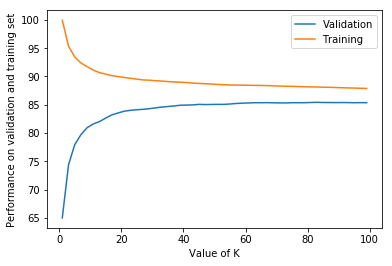

```python
plt.plot(K_Value_List_odd, Val_Score_Aw2v_bru, label="Validation")
plt.plot(K_Value_List_odd, Training_Score_Aw2v_bru, label="Training")
plt.xlabel("Value of K");
plt.ylabel("Performance on validation and training set")
plt.legend()
```

```python
%%time
from sklearn.metrics import roc_curve, auc

#computing difference of Training score and validation score
for_opt_k = []
for k in range(len(K_Value_List_odd)):
    for_opt_k.append(abs(Training_Score_Aw2v_bru[k] - Val_Score_Aw2v_bru[k]))

#K Value based on the min of diff bwn train and validation score
K_Value_to_train_Aw2v_bru = K_Value_List_odd[for_opt_k.index(min(for_opt_k))]
print(K_Value_to_train_Aw2v_bru)
#Training on K found
knn_to_fit_the_best = KNeighborsClassifier(n_neighbors=K_Value_to_train,algorithm='brute')
knn_to_fit_the_best.fit(X_train, Y_train)
#predicting values on test data
Prediction_test = knn_to_fit_the_best.predict(X_test)
#predicting probabilities on test data
Prediction_prob_test = knn_to_fit_the_best.predict_proba(X_test)

#predicting values on train data
Prediction_train = knn_to_fit_the_best.predict(X_train)
#predicting probabilities on train data
Prediction_prob_train = knn_to_fit_the_best.predict_proba(X_train)

#computing ROC curve parameters
fpr, tpr, thresholds = roc_curve( Y_train, Prediction_prob_train[:,1])
fpr_test, tpr_test, thresholds_test = roc_curve( Y_test, Prediction_prob_test[:,1])
#computing AUC value on prediction over train data
roc_auc_train_Aw2v_bru = auc(fpr, tpr)
#computing AUC value on prediction over test data
roc_auc_test_Aw2v_bru = auc(fpr_test, tpr_test)
```

```
99
Wall time: 37.7 s
```

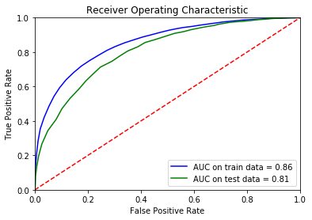

```python
#Plotting ROC Curve
import matplotlib.pyplot as plt
plt.title('Receiver Operating Characteristic')
plt.plot(fpr, tpr, 'b', label = 'AUC on train data = %0.2f' % roc_auc_train_Aw2v_bru)

plt.plot(fpr_test, tpr_test, 'g', label = 'AUC on test data = %0.2f' % roc_auc_test_Aw2v_bru)
plt.legend(loc = 'lower right')
plt.plot([0, 1], [0, 1],'r--')
plt.xlim([0, 1])
plt.ylim([0, 1])
plt.ylabel('True Positive Rate')
plt.xlabel('False Positive Rate')
plt.show()
```

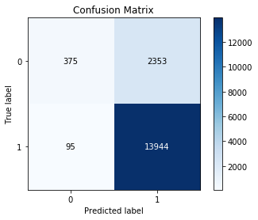

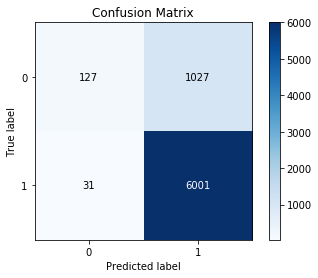

```python
#confusion matirx
import scikitplot.metrics as skplt
# for train data prediction
skplt.plot_confusion_matrix(Y_train, Prediction_train)
#for test data prediction
skplt.plot_confusion_matrix(Y_test, Prediction_test )
```

## ----------------------------- End of Avg W2V - Brute -----------------------------------

## Avg W2V - KdTree

```python
from sklearn import preprocessing
from sklearn.model_selection import train_test_split

sent_vectors = preprocessing.normalize(sent_vectors)

#Not shuffling the data as we want it on time basis
X_train, X_test, Y_train,Y_test = train_test_split(sent_vectors,final['Score'].values,test_size=0.3,shuffle=False)
print("The training and test dataset shape is:", X_train.shape,X_test.shape)
```

```
The training and test dataset shape is: (16767, 50) (7186, 50)
```

```python
%%time
TimeBasedSplittingMachine = TimeSeriesSplit(n_splits=10)
from sklearn.neighbors import KNeighborsClassifier
from sklearn.model_selection import cross_validate
from sklearn.metrics import precision_score, recall_score, roc_curve
from sklearn.model_selection import learning_curve

train_scores_Aw2v_kd=[]

i=1

for K in tqdm(K_Value_List_odd):
    #KNN for each K value using all processors
    KNN_model_Aw2v_kd = KNeighborsClassifier(n_neighbors = K,algorithm='kd_tree', n_jobs = -1)
    train_score = cross_validate(KNN_model_Aw2v_kd, X_train, Y_train, cv=8, scoring='roc_auc',return_train_score=True)
    train_scores_Aw2v_kd.append(train_score)
```

```
Wall time: 1h 27min 5s
```

```python
Val_Score_Aw2v_kd=[];
Training_Score_Aw2v_kd = []

for i in tqdm(train_scores_Aw2v_kd):
    Val_Score_Aw2v_kd.append(i.get('test_score').mean()*100)
    Training_Score_Aw2v_kd.append(i.get('train_score').mean()*100)
```

```
Text(99,80.4153,'(99,80.41525068323263)')
```

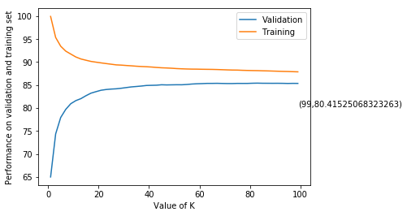

```python
plt.plot(K_Value_List_odd, Val_Score_Aw2v_kd, label="Validation")
plt.plot(K_Value_List_odd, Training_Score_Aw2v_kd, label="Training")
plt.xlabel("Value of K");
plt.ylabel("Performance on validation and training set")
plt.legend()
plt.annotate('(%s,%s)'%xy, xy=xy, textcoords='data')
```

```python
%%time
from sklearn.metrics import roc_curve, auc

#computing difference of Training score and validation score
for_opt_k = []
for k in range(len(K_Value_List_odd)):
    for_opt_k.append(Training_Score_Aw2v_kd[k] - Val_Score_Aw2v_kd[k])

#K Value based on the min of diff bwn train and validation score
K_Value_to_train_Aw2v_kd = K_Value_List_odd[for_opt_k.index(min(for_opt_k))]
print(K_Value_to_train_Aw2v_kd)
#Training on K found
knn_to_fit_the_best = KNeighborsClassifier(n_neighbors=K_Value_to_train_Aw2v_kd,algorithm='brute')
knn_to_fit_the_best.fit(X_train, Y_train)
#predicting values on test data
Prediction_test = knn_to_fit_the_best.predict(X_test)
#predicting probabilities on test data
Prediction_prob_test = knn_to_fit_the_best.predict_proba(X_test)

#predicting values on train data
Prediction_train = knn_to_fit_the_best.predict(X_train)
#predicting probabilities on train data
Prediction_prob_train = knn_to_fit_the_best.predict_proba(X_train)

#computing ROC curve parameters
fpr, tpr, thresholds = roc_curve( Y_train, Prediction_prob_train[:,1])
fpr_test, tpr_test, thresholds_test = roc_curve( Y_test, Prediction_prob_test[:,1])
#computing AUC value on prediction over train data
roc_auc_train_Aw2v_kd = auc(fpr, tpr)
#computing AUC value on prediction over test data
roc_auc_test_Aw2v_kd = auc(fpr_test, tpr_test)

#### [4.4.1.2] TFIDF weighted W2v
```

```
99
Wall time: 38 s
```

```python
#Plotting ROC Curve
import matplotlib.pyplot as plt
plt.title('Receiver Operating Characteristic')
plt.plot(fpr, tpr, 'b', label = 'AUC on train data = %0.2f' % roc_auc_train_Aw2v_kd)

plt.plot(fpr_test, tpr_test, 'g', label = 'AUC on test data = %0.2f' % roc_auc_test_Aw2v_kd)
plt.legend(loc = 'lower right')
plt.plot([0, 1], [0, 1],'r--')
plt.xlim([0, 1])
plt.ylim([0, 1])
plt.ylabel('True Positive Rate')
plt.xlabel('False Positive Rate')
plt.show()
```

```python
#confusion matirx
import scikitplot.metrics as skplt
# for train data prediction
skplt.plot_confusion_matrix(Y_train, Prediction_train)
#for test data prediction
skplt.plot_confusion_matrix(Y_test, Prediction_test )
```

# TFIDF W2V

```python
# S = ["abc def pqr", "def def def abc", "pqr pqr def"]
model = TfidfVectorizer()
tf_idf_matrix = model.fit_transform(preprocessed_reviews)
# we are converting a dictionary with word as a key, and the idf as a value
dictionary = dict(zip(model.get_feature_names(), list(model.idf_)))
```

```python
# TF-IDF weighted Word2Vec
tfidf_feat = model.get_feature_names() # tfidf words/col-names
# final_tf_idf is the sparse matrix with row= sentence, col=word and cell_val = tfidf

tfidf_sent_vectors = []; # the tfidf-w2v for each sentence/review is stored in this list
row=0;
for sent in tqdm(list_of_sentance): # for each review/sentence
    sent_vec = np.zeros(50) # as word vectors are of zero length
    weight_sum =0; # num of words with a valid vector in the sentence/review
    for word in sent: # for each word in a review/sentence
        if word in w2v_words and word in tfidf_feat:
            vec = w2v_model.wv[word]
#             tf_idf = tf_idf_matrix[row, tfidf_feat.index(word)]
            # to reduce the computation we are
            # dictionary[word] = idf value of word in whole courpus
            # sent.count(word) = tf valeus of word in this review
            tf_idf = dictionary[word]*(sent.count(word)/len(sent))
            sent_vec += (vec * tf_idf)
            weight_sum += tf_idf
    if weight_sum != 0:
        sent_vec /= weight_sum
    tfidf_sent_vectors.append(sent_vec)
    row += 1
```

## TfIdf - W2v- Brute

```python
from sklearn import preprocessing
from sklearn.model_selection import train_test_split

tfidf_sent_vectors = preprocessing.normalize(tfidf_sent_vectors)

#Not shuffling the data as we want it on time basis
X_train, X_test, Y_train,Y_test = train_test_split(tfidf_sent_vectors,final['Score'].values,test_size=0.3,shuffle=False)
print("The training and test dataset shape is:", X_train.shape,X_test.shape)
```

```
The training and test dataset shape is: (16767, 50) (7186, 50)
```

```python
%%time
TimeBasedSplittingMachine = TimeSeriesSplit(n_splits=10)
from sklearn.neighbors import KNeighborsClassifier
from sklearn.model_selection import cross_validate
from sklearn.metrics import precision_score, recall_score, roc_curve
from sklearn.model_selection import learning_curve

train_scores_TW2v_bru=[]

i=1

for K in tqdm(K_Value_List_odd):
    #KNN for each K value using all processors
    KNN_model_TW2v_bru = KNeighborsClassifier(n_neighbors = K,algorithm='brute', n_jobs = -1)
    train_score = cross_validate(KNN_model_TW2v_bru, X_train, Y_train, cv=10, scoring='roc_auc',return_train_score=True)
    train_scores_TW2v_bru.append(train_score)
```

```
Wall time: 2h 43min 6s
```

```python
Val_Score_TW2v_bru=[];
Training_Score_TW2v_bru = []

for i in tqdm(train_scores_TW2v_bru):
    Val_Score_TW2v_bru.append(i.get('test_score').mean()*100)
    Training_Score_TW2v_bru.append(i.get('train_score').mean()*100)
```

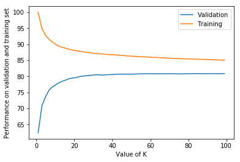

```python
plt.plot(K_Value_List_odd, Val_Score_TW2v_bru, label="Validation")
plt.plot(K_Value_List_odd, Training_Score_TW2v_bru, label="Training")
plt.xlabel("Value of K");
plt.ylabel("Performance on validation and training set")
plt.legend()
```

```python
%%time
from sklearn.metrics import roc_curve, auc

#computing difference of Training score and validation score
for_opt_k = []
for k in range(len(K_Value_List_odd)):
    for_opt_k.append(Training_Score_TW2v_bru[k] - Val_Score_TW2v_bru[k])

#K Value based on the min of diff bwn train and validation score
K_Value_to_train_TW2v_bru = K_Value_List_odd[for_opt_k.index(min(for_opt_k))]
print(K_Value_to_train_TW2v_bru)
#Training on K found
knn_to_fit_the_best = KNeighborsClassifier(n_neighbors=K_Value_to_train_TW2v_bru,algorithm='brute')
knn_to_fit_the_best.fit(X_train, Y_train)
#predicting values on test data
Prediction_test = knn_to_fit_the_best.predict(X_test)
#predicting probabilities on test data
Prediction_prob_test = knn_to_fit_the_best.predict_proba(X_test)

#predicting values on train data
Prediction_train = knn_to_fit_the_best.predict(X_train)
#predicting probabilities on train data
Prediction_prob_train = knn_to_fit_the_best.predict_proba(X_train)

#computing ROC curve parameters
fpr, tpr, thresholds = roc_curve( Y_train, Prediction_prob_train[:,1])
fpr_test, tpr_test, thresholds_test = roc_curve( Y_test, Prediction_prob_test[:,1])
#computing AUC value on prediction over train data
roc_auc_train_TW2v_bru = auc(fpr, tpr)
#computing AUC value on prediction over test data
roc_auc_test_TW2v_bru = auc(fpr_test, tpr_test)
```

```
99
Wall time: 36.2 s
```

```python
#Plotting ROC Curve
import matplotlib.pyplot as plt
plt.title('Receiver Operating Characteristic')
plt.plot(fpr, tpr, 'b', label = 'AUC on train data = %0.2f' % roc_auc_train_TW2v_bru)

plt.plot(fpr_test, tpr_test, 'g', label = 'AUC on test data = %0.2f' % roc_auc_test_TW2v_bru)
plt.legend(loc = 'lower right')
plt.plot([0, 1], [0, 1],'r--')
plt.xlim([0, 1])
plt.ylim([0, 1])
plt.ylabel('True Positive Rate')
plt.xlabel('False Positive Rate')
plt.show()
```

```python
#confusion matirx
import scikitplot.metrics as skplt
# for train data prediction
skplt.plot_confusion_matrix(Y_train, Prediction_train)
#for test data prediction
skplt.plot_confusion_matrix(Y_test, Prediction_test )
```

## Avg W2V TfIdf - KdTree

```python
from sklearn import preprocessing
from sklearn.model_selection import train_test_split

tfidf_sent_vectors = preprocessing.normalize(tfidf_sent_vectors)

#Not shuffling the data as we want it on time basis
X_train, X_test, Y_train,Y_test = train_test_split(tfidf_sent_vectors,final['Score'].values,test_size=0.3,shuffle=False)

print("The training and test dataset shape is:", X_train.shape,X_test.shape)
```

```
The training and test dataset shape is: (16767, 50) (7186, 50)
```

```python
%%time
#TimeBasedSplittingMachine = TimeSeriesSplit(n_splits=10)
from sklearn.neighbors import KNeighborsClassifier
from sklearn.model_selection import cross_validate
from sklearn.metrics import precision_score, recall_score, roc_curve
from sklearn.model_selection import learning_curve

train_scores_TW2v_kd=[]

i=1

for K in tqdm(K_Value_List_odd):
    #KNN for each K value using all processors
    KNN_model_TW2v_kd = KNeighborsClassifier(n_neighbors = K,algorithm='kd_tree', n_jobs = -1)
    train_score = cross_validate(KNN_model_TW2v_kd, X_train, Y_train, cv=10, scoring='roc_auc',return_train_score=True)
    train_scores_TW2v_kd.append(train_score)
```

```
Wall time: 1h 42min 25s
```

```python
Val_Score_TW2v_kd=[];
Training_Score_TW2v_kd = []

for i in tqdm(train_scores_TW2v_kd):
    Val_Score_TW2v_kd.append(i.get('test_score').mean()*100)
    Training_Score_TW2v_kd.append(i.get('train_score').mean()*100)
```

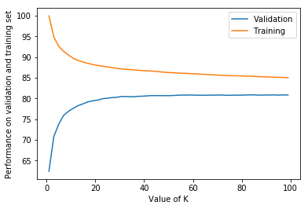

```python
plt.plot(K_Value_List_odd, Val_Score_TW2v_kd, label="Validation")
plt.plot(K_Value_List_odd, Training_Score_TW2v_kd, label="Training")
plt.xlabel("Value of K");
plt.ylabel("Performance on validation and training set")
plt.legend()
```

```python
%%time
from sklearn.metrics import roc_curve, auc

#computing difference of Training score and validation score
for_opt_k = []
for k in range(len(K_Value_List_odd)):
    for_opt_k.append(Training_Score_TW2v_kd[k] - Val_Score_TW2v_kd[k])

#K Value based on the min of diff bwn train and validation score
K_Value_to_train_TW2v_kd = K_Value_List_odd[for_opt_k.index(min(for_opt_k))]
print(K_Value_to_train_TW2v_kd)
#Training on K found
knn_to_fit_the_best = KNeighborsClassifier(n_neighbors=K_Value_to_train_TW2v_kd,algorithm='brute')
knn_to_fit_the_best.fit(X_train, Y_train)
#predicting values on test data
Prediction_test = knn_to_fit_the_best.predict(X_test)
#predicting probabilities on test data
Prediction_prob_test = knn_to_fit_the_best.predict_proba(X_test)

#predicting values on train data
Prediction_train = knn_to_fit_the_best.predict(X_train)
#predicting probabilities on train data
Prediction_prob_train = knn_to_fit_the_best.predict_proba(X_train)

#computing ROC curve parameters
fpr, tpr, thresholds = roc_curve( Y_train, Prediction_prob_train[:,1])
fpr_test, tpr_test, thresholds_test = roc_curve( Y_test, Prediction_prob_test[:,1])
#computing AUC value on prediction over train data
roc_auc_train_TW2v_kd = auc(fpr, tpr)
#computing AUC value on prediction over test data
roc_auc_test_TW2v_kd = auc(fpr_test, tpr_test)
```

```
99
Wall time: 37.7 s
```

```python
#Plotting ROC Curve
import matplotlib.pyplot as plt
plt.title('Receiver Operating Characteristic')
plt.plot(fpr, tpr, 'b', label = 'AUC on train data = %0.2f' % roc_auc_train_TW2v_kd)

plt.plot(fpr_test, tpr_test, 'g', label = 'AUC on test data = %0.2f' % roc_auc_test_TW2v_kd)
plt.legend(loc = 'lower right')
plt.plot([0, 1], [0, 1],'r--')
plt.xlim([0, 1])
plt.ylim([0, 1])
plt.ylabel('True Positive Rate')
plt.xlabel('False Positive Rate')
plt.show()
```

```python
#confusion matirx
import scikitplot.metrics as skplt
# for train data prediction
skplt.plot_confusion_matrix(Y_train, Prediction_train)
#for test data prediction
skplt.plot_confusion_matrix(Y_test, Prediction_test )
```

```python
from prettytable import PrettyTable
X = PrettyTable()
X.field_names = ["vectorizer","Algorithm","Optimal-K Value","AUC on train","AUC on Test"]
X.add_row(["BoW","Brute",K_Value_to_train_bow_bru, roc_auc_train, roc_auc_test])
X.add_row(["BoW","Kd-Tree",K_Value_to_train,roc_auc_train_Bow_kd, roc_auc_test_Bow_kd])
X.add_row(["TfIdf","Brute",K_Value_to_train_tfidf_bru,roc_auc_train_tfidf_bru, roc_auc_test_tfidf_bru])
X.add_row(["TfIdf","Kd-Tree",K_Value_to_train_tf_kd,roc_auc_train_tfidf_kd, roc_auc_test_tfidf_kd])
X.add_row(["Avg W2V","Brute",K_Value_to_train_Aw2v_bru,roc_auc_train_Aw2v_bru, roc_auc_test_Aw2v_bru])
X.add_row(["Avg W2V","Kd-Tree",K_Value_to_train_Aw2v_kd,roc_auc_train_Aw2v_kd, roc_auc_test_Aw2v_kd])
X.add_row(["Avg TfIdf W2V","Brute",K_Value_to_train_TW2v_bru,roc_auc_train_TW2v_bru, roc_auc_test_TW2v_kd])
X.add_row(["Avg TfIdf W2V","Kd-Tree",K_Value_to_train_TW2v_kd,roc_auc_train_TW2v_kd,roc_auc_test_TW2v_kd])
print(X)
```

[output not shown]